# IODS course project

**Clusters**

```r
library(MASS)
str(Boston)
```

```
## 'data.frame':    506 obs. of  14 variables:
##  $ crim   : num  0.00632 0.02731 0.02729 0.03237 0.06905 ...
##  $ zn     : num  18 0 0 0 0 0 12.5 12.5 12.5 12.5 ...
##  $ indus  : num  2.31 7.07 7.07 2.18 2.18 2.18 7.87 7.87 7.87 7.87 ...
##  $ chas   : int  0 0 0 0 0 0 0 0 0 0 ...
##  $ nox    : num  0.538 0.469 0.469 0.458 0.458 0.458 0.524 0.524 0.524 0.524 ...
##  $ rm     : num  6.58 6.42 7.18 7 7.15 ...
##  $ age    : num  65.2 78.9 61.1 45.8 54.2 58.7 66.6 96.1 100 85.9 ...
##  $ dis    : num  4.09 4.97 4.97 6.06 6.06 ...
##  $ rad    : int  1 2 2 3 3 3 5 5 5 5 ...
##  $ tax    : num  296 242 242 222 222 222 311 311 311 311 ...
##  $ ptratio: num  15.3 17.8 17.8 18.7 18.7 18.7 15.2 15.2 15.2 15.2 ...
##  $ black  : num  397 397 393 395 397 ...
##  $ lstat  : num  4.98 9.14 4.03 2.94 5.33 ...
##  $ medv   : num  24 21.6 34.7 33.4 36.2 28.7 22.9 27.1 16.5 18.9 ...
```

```r
dim(Boston)
```

```
## [1] 506  14
```

Details about the Boston dataset can be seen here: https://stat.ethz.ch/R-manual/R-devel/library/MASS/html/Boston.html. It has 506 observations of 14 variables.

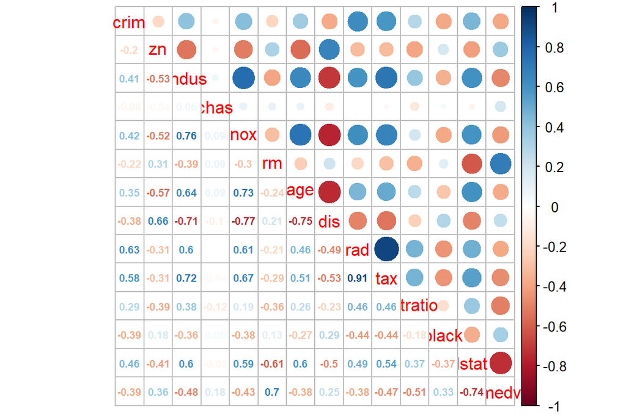

```r
library(corrplot)
library(tidyverse)
cor_matrix <- cor(Boston)
corrplot.mixed(cor_matrix, number.cex = .6)
```

```r
boston_scaled <- scale(Boston)
summary(boston_scaled)
```

```
##       crim                 zn               indus
##  Min.   :-0.419367   Min.   :-0.48724   Min.   :-1.5563
##  1st Qu.:-0.410563   1st Qu.:-0.48724   1st Qu.:-0.8668
##  Median :-0.390280   Median :-0.48724   Median :-0.2109
##  Mean   : 0.000000   Mean   : 0.00000   Mean   : 0.0000
##  3rd Qu.: 0.007389   3rd Qu.: 0.04872   3rd Qu.: 1.0150
##  Max.   : 9.924110   Max.   : 3.80047   Max.   : 2.4202
##       chas              nox                rm               age
##  Min.   :-0.2723   Min.   :-1.4644   Min.   :-3.8764   Min.   :-2.3331
##  1st Qu.:-0.2723   1st Qu.:-0.9121   1st Qu.:-0.5681   1st Qu.:-0.8366
##  Median :-0.2723   Median :-0.1441   Median :-0.1084   Median : 0.3171
##  Mean   : 0.0000   Mean   : 0.0000   Mean   : 0.0000   Mean   : 0.0000
##  3rd Qu.:-0.2723   3rd Qu.: 0.5981   3rd Qu.: 0.4823   3rd Qu.: 0.9059
##  Max.   : 3.6648   Max.   : 2.7296   Max.   : 3.5515   Max.   : 1.1164
##       dis               rad               tax             ptratio
##  Min.   :-1.2658   Min.   :-0.9819   Min.   :-1.3127   Min.   :-2.7047
##  1st Qu.:-0.8049   1st Qu.:-0.6373   1st Qu.:-0.7668   1st Qu.:-0.4876
##  Median :-0.2790   Median :-0.5225   Median :-0.4642   Median : 0.2746
##  Mean   : 0.0000   Mean   : 0.0000   Mean   : 0.0000   Mean   : 0.0000
##  3rd Qu.: 0.6617   3rd Qu.: 1.6596   3rd Qu.: 1.5294   3rd Qu.: 0.8058
##  Max.   : 3.9566   Max.   : 1.6596   Max.   : 1.7964   Max.   : 1.6372
##      black             lstat              medv
##  Min.   :-3.9033   Min.   :-1.5296   Min.   :-1.9063
##  1st Qu.: 0.2049   1st Qu.:-0.7986   1st Qu.:-0.5989
##  Median : 0.3808   Median :-0.1811   Median :-0.1449
##  Mean   : 0.0000   Mean   : 0.0000   Mean   : 0.0000
##  3rd Qu.: 0.4332   3rd Qu.: 0.6024   3rd Qu.: 0.2683
##  Max.   : 0.4406   Max.   : 3.5453   Max.   : 2.9865
```

```r
boston_scaled <- as.data.frame(boston_scaled)
```

After scaling the mean of all variables is 0, as all of them have the same scale now.

```r
bins <- quantile(boston_scaled$crim)
crime <- cut(boston_scaled$crim, breaks = bins, inlcude.lowest = TRUE, label = c("low", "med_low", "med_high", "high"))
table(crime)
```

```
## crime
##      low  med_low med_high     high
##      126      126      126      127
```

```r
boston_scaled <- dplyr::select(boston_scaled, -crim)
boston_scaled <- data.frame(boston_scaled, crime)
n <- nrow(boston_scaled)
ind <- sample(n, size = n*0.8)
train <- boston_scaled[ind,]
test <- boston_scaled[-ind,]
```

We have created a categorical variable of the crime rate from the scaled crime rate, while using the quantiles as the break points in the categorical variable. After that we omit old variable from the dataset. Then we chose randomly 80% of the rows and created two sets for training and test.

```r
lda.fit <- lda(crime ~., data = train)
lda.fit
```

```
## Call:
## lda(crime ~ ., data = train)
##
## Prior probabilities of groups:
##       low   med_low  med_high      high
## 0.2481390 0.2406948 0.2506203 0.2605459
##
## Group means:
##                   zn      indus        chas        nox         rm
## low       0.94099723 -0.9540149 -0.15421606 -0.8805325  0.4912713
## med_low  -0.06664642 -0.2544991  0.05238023 -0.5618723 -0.1752877
## med_high -0.38365582  0.1503911  0.11748284  0.3684150  0.1757774
## high     -0.48724019  1.0170492 -0.08484810  1.0323710 -0.4482643
##                 age        dis        rad        tax     ptratio
## low      -0.9016315  0.8893400 -0.6832698 -0.7351921 -0.42427562
## med_low  -0.2942623  0.4158289 -0.5355082 -0.4706971 -0.08136563
## med_high  0.4309602 -0.3606846 -0.4235570 -0.3317395 -0.27672657
## high      0.8046795 -0.8508012  1.6388211  1.5145512  0.78158339
##               black        lstat        medv
## low       0.3795183 -0.793868423  0.57128783
## med_low   0.3097304 -0.083627196 -0.04190272
## med_high  0.1039665  0.008125664  0.21550753
## high     -0.7312207  0.876644858 -0.71652437
##
## Coefficients of linear discriminants:
##                 LD1         LD2         LD3
## zn       0.10721905  0.63102868 -0.82132195
## indus    0.06971889 -0.19916561  0.58433472
## chas    -0.07645136 -0.06015152  0.23321802
## nox      0.33985569 -0.74813738 -1.38178767
## rm      -0.10745382 -0.14774142 -0.23905843
## age      0.21357605 -0.37934743 -0.02346526
## dis     -0.07361489 -0.20455356  0.32625376
## rad      3.39995125  0.97114124  0.04540897
## tax      0.01651396 -0.02160387  0.33200963
## ptratio  0.14968912 -0.06595410 -0.39921954
## black   -0.10981535  0.05279527  0.12857348
## lstat    0.28609827 -0.26495144  0.32874492
## medv     0.22557397 -0.43293502 -0.24233514
##
## Proportion of trace:
##    LD1    LD2    LD3
## 0.9530 0.0342 0.0127
```